# Characterizing Seattle Police Department’s Civilian Interactions

Madeleine Clarke, Allison Huang, Sean Kim, Ivy Li

11/14/2022

## Summary paragraph:

The goal of our project was to better understand trends in Seattle Police Department’s (SPD) policing practices. More specifically, we were interested in revealing any troubling patterns in the ways SPD was stopping civilians, using force, or shooting. By analyzing 3 datasets obtained from the SPD, we hoped to reveal any racial biases in policing as well as what areas of the city saw the most police action. Some of the main findings in our analysis are described below.

For one, we found that the Terry Stops dataset showed there were 5 types of interactions: **Field Contact, Arrest, Citation / Infraction, Offense Report, Referred for Prosecution**. Of these, the most common type of Terry Stop was **Field Contact**. Further, the most stopped racial group was White individuals (26334), however despite making up only 7.06% of the Seattle population, Black individuals were the second most stopped racial group (15946). When analyzing the Use of Force dataset, we found that the most frequent type of force used was **Level 1 - Use of Force**, which is the least extreme form of police force. Our dataset showed that Level 1 - Use of Force was utilized **931** times between 2014 and 2022. When analyzing the most extreme form of police violence, Officer Involved Shootings, our analysis revealed that the ratio of shootings against Black individuals compared to White individuals was **0.7142857**. However, the population ratio for Black and White people in Seattle is **0.1072785**. This finding indicates that there was potential racial bias present in the shooting data.

## Table of Summary Information

Gender Stop Counts

| Gender | Stop Counts | Percentage |
| --- | --- | --- |
| - | 239 | 0.45 |
| DUPLICATE | 2 | 0.00 |
| Female | 10756 | 20.04 |
| Gender Diverse (gender non-conforming and/or transgender) | 20 | 0.04 |
| Male | 42273 | 78.75 |
| Unable to Determine | 326 | 0.61 |
| Unknown | 67 | 0.12 |

Race Stop Counts

| Race | Stop Counts | Percentage |
| --- | --- | --- |
| - | 1810 | 3.37 |
| American Indian or Alaska Native | 1515 | 2.82 |
| Asian | 1803 | 3.36 |
| Black or African American | 15946 | 29.70 |
| DUPLICATE | 2 | 0.00 |
| Hispanic | 1684 | 3.14 |
| Multi-Racial | 809 | 1.51 |
| Native Hawaiian or Other Pacific Islander | 99 | 0.18 |
| Other | 152 | 0.28 |
| Unknown | 3529 | 6.57 |
| White | 26334 | 49.05 |

Geography Stop Counts

| Geography | Stop Counts | Percentage |
| --- | --- | --- |
| - | 10242 | 19.08 |
| East | 6907 | 12.87 |
| FK ERROR | 22 | 0.04 |
| North | 11707 | 21.81 |
| OOJ | 61 | 0.11 |
| South | 6365 | 11.86 |
| Southwest | 2320 | 4.32 |
| SouthWest | 1779 | 3.31 |
| Unknown | 200 | 0.37 |
| West | 14080 | 26.23 |

Interaction Stop Counts

| Interaction | Stop Counts | Percentage |
| --- | --- | --- |
| Arrest | 8210 | 15.29 |
| Citation / Infraction | 271 | 0.50 |
| Field Contact | 31279 | 58.27 |
| Offense Report | 13197 | 24.58 |
| Referred for Prosecution | 726 | 1.35 |

### Findings from data in tables

Table 1: For gender, males got stopped the most.

Table 2: White and black got stopped the most. This could mean a bias of police towards black people.

Table 3: North and West got the most people stopped. It could mean these two areas are not as safe as other areas.

Table 4: For interactions, field contact is the most.

## Chart 1: Bar Chart

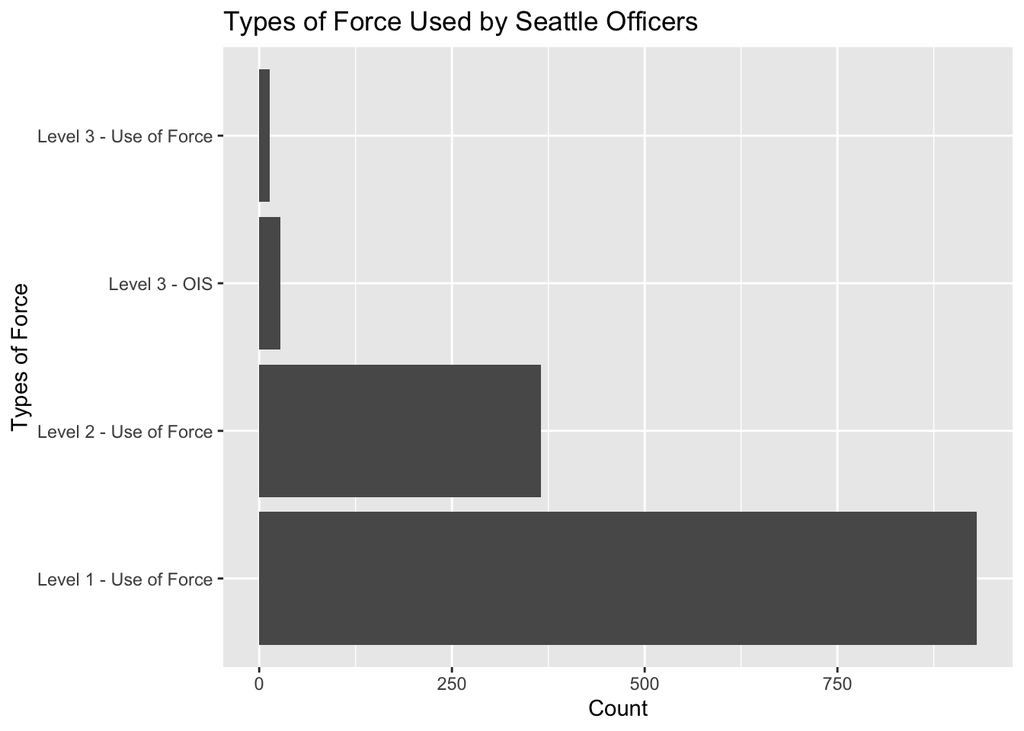

## Chart 2: Pie Chart

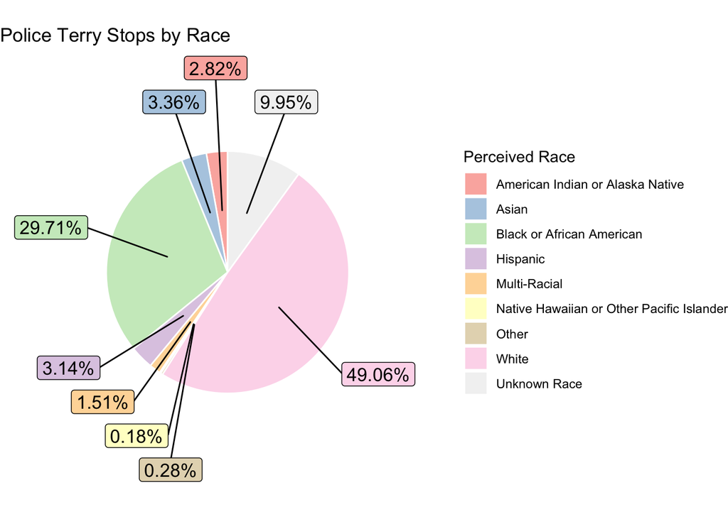

The purpose of the created pie chart is to display visually the perceived races of the people that are stopped by police based on data from the SPD, so that any disparities between the number of stops for different races, as well as variances from the overall Seattle demographics can be acknowledged. From the pie chart, it can be seen that people of the perceived race of White is the group that is stopped the most by police. The second group of people with the greatest number of stops would be people that belong to the Black or African American race. The chart also displays numerous other races and how much they are stopped in comparison to those of other racial groups. The data from the chart can be used to compare to overall Seattle demographics. For the White people, the groups seem to correspond, with the group being the largest demographic in Seattle, and also being the group that is stopped the most by police. However, the contrast in some groups are significant. Specifically, it is concerning how much greater, at 29.71% of Black people are stopped by police, while they only compose of 7.06% of the population of the city of Seattle.

## Chart 3: Map

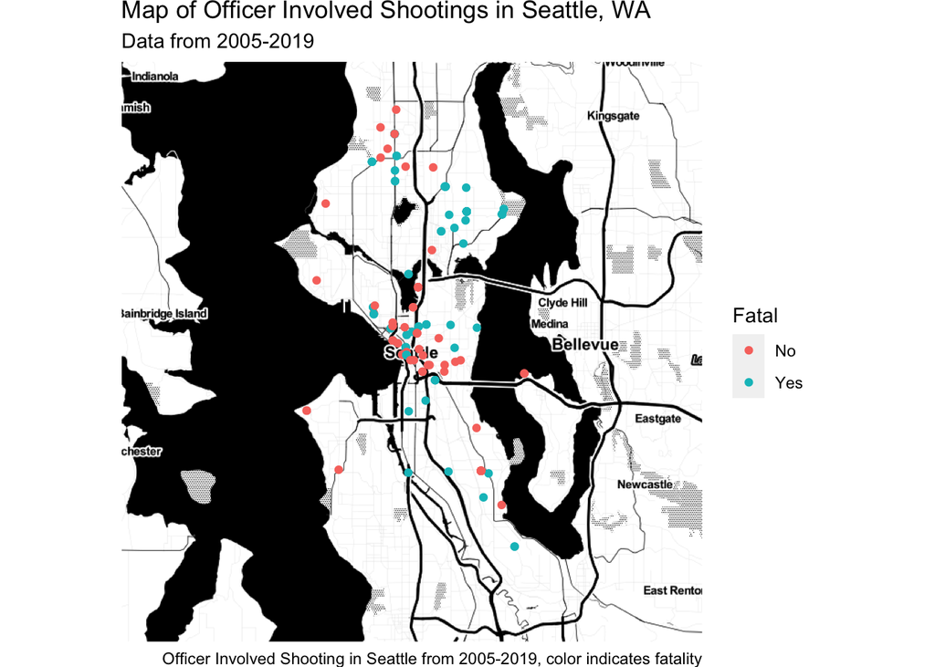

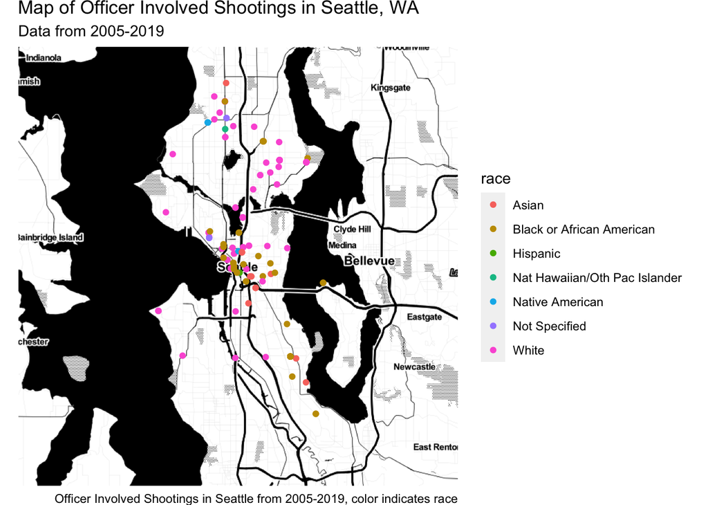

This visualization seeks to geographically plot the most extreme form of police violence, *Officer Involved Shootings*. This plot was included because it allows us to visualize where in Seattle shootings have occurred. While it would have been valuable to plot the geographical distribution of all the of the interactions we are analyzing (Terry Stops and Use of Force, too), the Officer Involved Shootings (OIS) dataset was the only set that included detailed location data. The longitude and latitude points included in the OIS dataset made for straightforward plotting.

By plotting these 156 instances of OIS on a map of Seattle, one can observe that a large cluster of shootings occurred in the city center, in Downtown Seattle and the surrounding areas. One can also observe the noticeable absence of shootings in North Seattle neighborhoods like Ballard, Fremont, Magnolia and Queen Anne as well as the neighborhood of Madison Park. Perhaps unsurprisingly, these are some of the wealthier (and whiter) neighborhoods in the city. The color of the dots on each respective map indicate fatality, or the race of the subject. While the map is useful for understanding the geographical distribution of shootings, these sub-trends are more easily understood by summary statistics, or a different type of visualization.